# Part II - (San Francisco Ford GoBike Data Exploration)

## by (Saddick Kwao Umar)

## Investigation Overview

> In this investigation, my focus or objective has been to determine how both dependent and independent features like age, user_type, gender, time, days and ofcourse day periods influenced trips duration and amount of trips taken.

## Dataset Overview

> The dataset contains 183,412 records of trips, and 16 different features including start time, end time, start station, end station, and latitude/longitude for each station.The dataset contains few numeric variables and categorical variables.

## Distribution of Trips Taken

> Trip duration distribution was far left due to it being highly skewed to the right, showing how it's mean is affected by outliers. After undergong log transformation, it could be observed that its distribution looks unimodal and that most trips lasted in between 300 to 600.

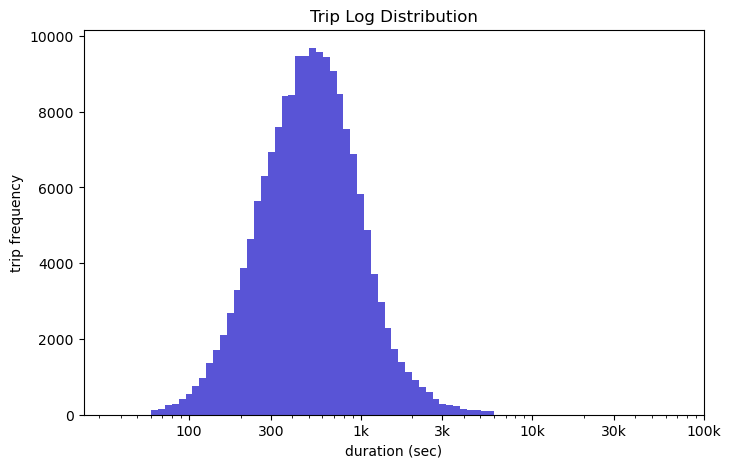

## Age Distribution of Go Bike Users

> The visualization here shows the age distribution of Go Bike users, where large chunks of riders fall within age brackets of 30 to 40 years in both gender. Nonetheless, it could be seen that the amount of male riders in each age bracket is far exceeds other gender.

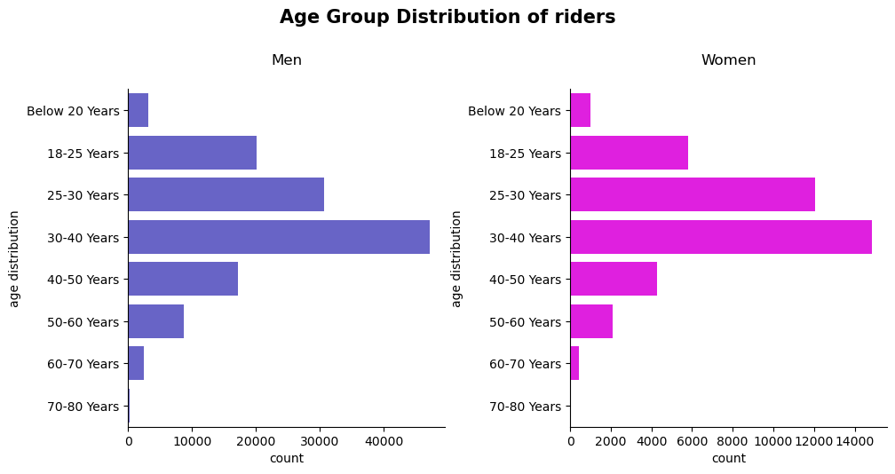

## GoBike User Type Subscription Ratio

> From the visualization, most Go Bike users tend to be under a subscription package with 90.7% of it users under a subscription package and 9.3% casual riders.

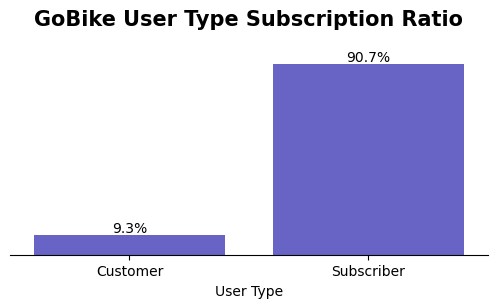

## GoBike Bike Share for All Trip Subscription Ratio

> There's very less subscription for the "bike share for all" program. Only 9.9% of riders agreed to subscribe to Go Bike's bike for all trip program with 90.1% declining.

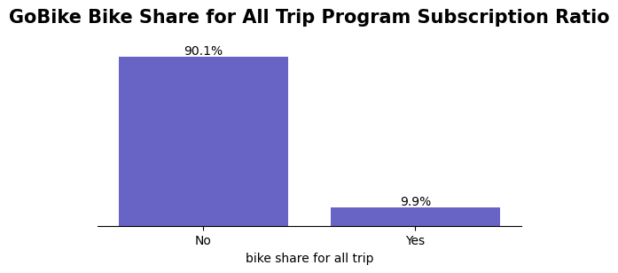

## GoBike Gender Subscription Ratio

Moreover, cycling and bike share are often male dominated, and here is no exception. The visualization show that 74.6% riders appear to be males and 23.3% are females, other gender 2.1%

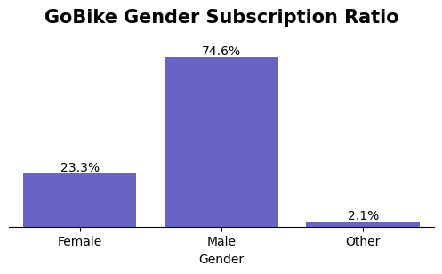

## Trip Frequency by Hour and Day

> Unsurprisingly, most trips were made during morning and afternoon. The peak in this hours shows that GoBike is popular with office commuters and students with frequency of bike sharing peaking at 8am to 9am during office and school going time and from 5pm to 6pm during office and school closing times. Also, Thursdays happens to be most popular with riders, whilst there isn't much biking during weekends.

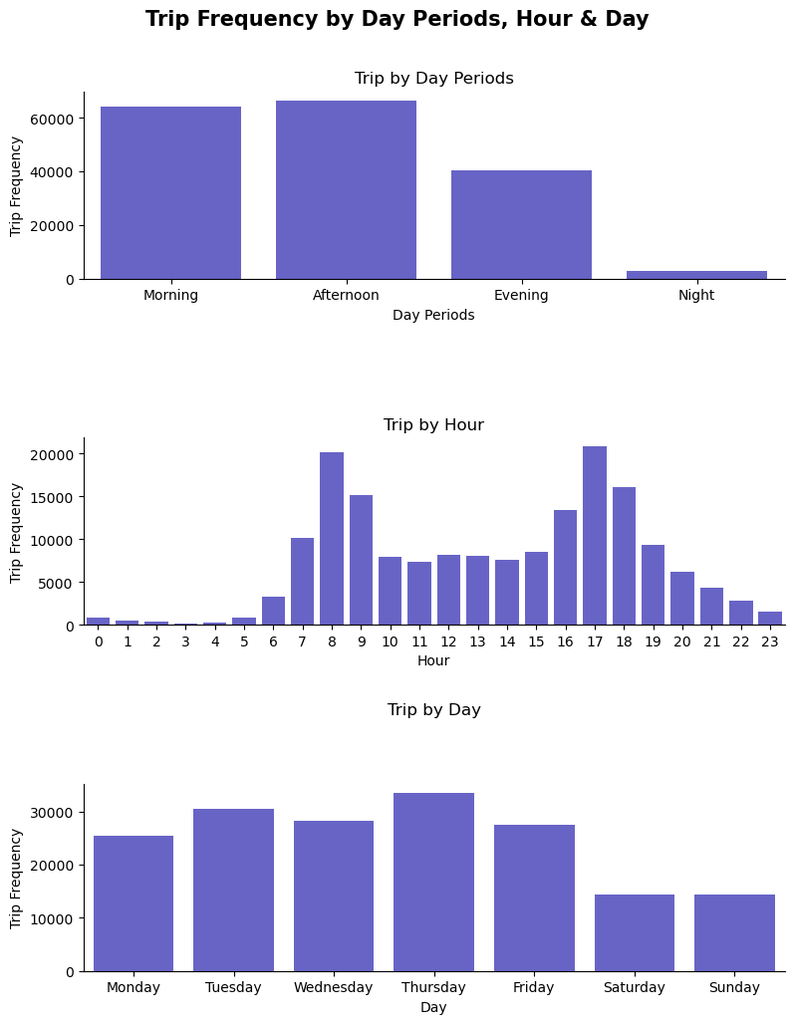

## Relationship between Bikers by Age and Trip Frequency

> Notice the negative trend between the bikers age and the time spent biking. With peaks between 330 to 600 seconds and age ranging from 25 to 35, the heatmap depicts most trips taken to be short trips and by people within working class and college going age. Importantly, the visualization shows a less trips are taken has users age.

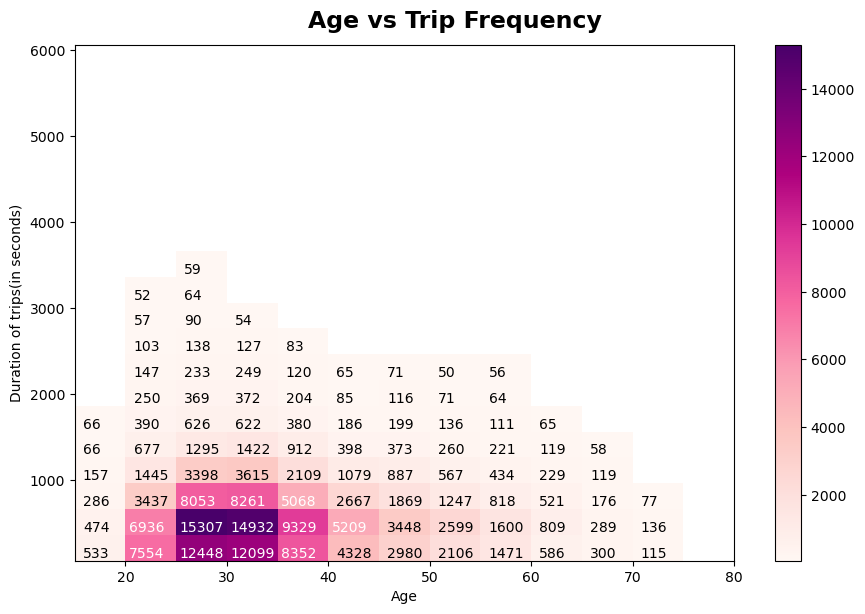

## GoBike User Type Trip Ratio by Day

> The visualization shows that casual riders tend to make 7% to 15% of the trips taken each day. This only shows they are unmotivated to subscribe to a package despite their tendencies to use bikes as means of transportation. To push unsuscribers towards subscription package, Go bikes might consider a little increase in unsuscriber fees.

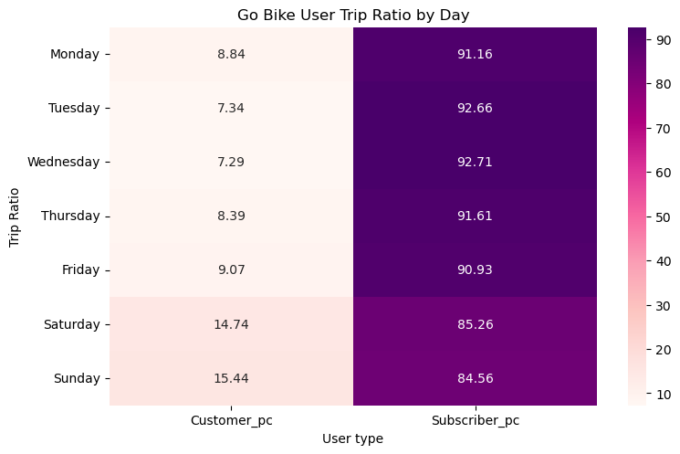

# GoBike Average Trip Duration Each Day by Gender

> From the visualization it can be observed that males tend to make short trips or complete trips quicker every single day. Whereas, females and other gender tend to make less but long trips hence leading to higher average duration.

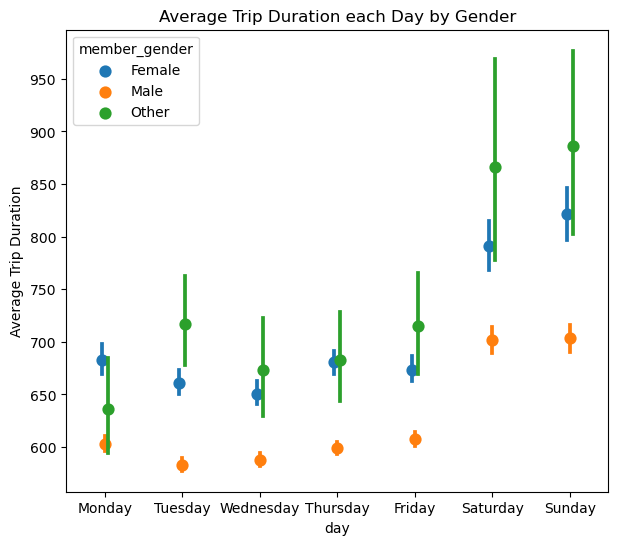